# Predator, prey and strandings: An IBM approach to modelling the ‘Blue Fleet’

# 4. Results

## 4.1 Beaching Probabilities

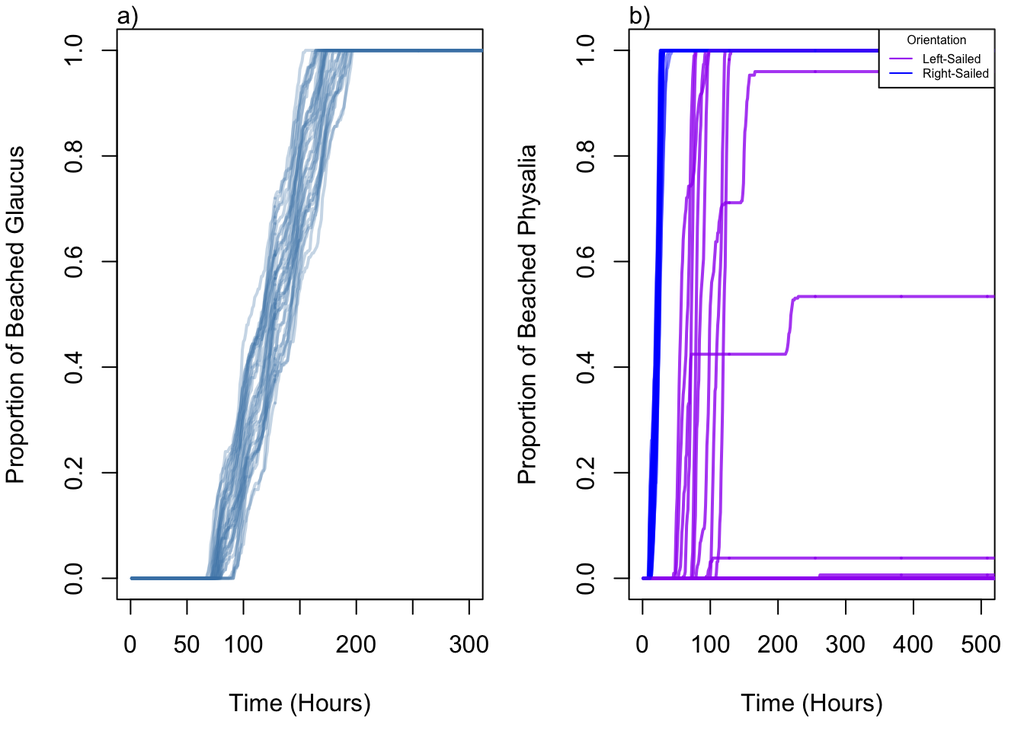

**Figure 1.** Proportion of beached individuals over time. Subplot a) shows beaching proportions for *Glaucus atlanticus*, subplot b) shows beaching proportions for *Physalia physalis*. Each line represents results from a single simulation run over 500 hours (out of 32 total simulations).

## 4.2 Predator-Prey Interactions

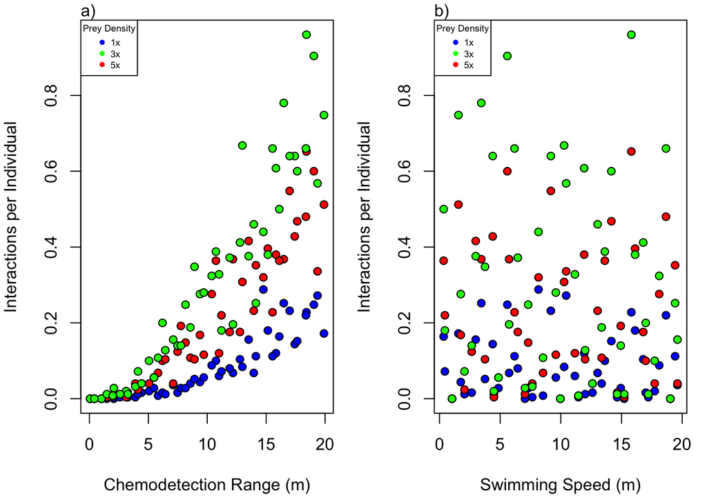

**Figure 2.** The effect of swimming speed and chemodetection range on the number of interactions between *G. atlanticus* and *P. physalis*. Each point represents a single simulation, each with a unique combination of swimming speed and chemodetection range obtained from a latine square sampling design. Colour represents prey density relative to predators. An interaction is defined as prey being in the immediate proximity of a predator, such that a predator can sense it and alters its behavioral movement.

# 5. Conclusion

## 5.1 The Blue Fleet: a loose assemblage?

The results from this work show that *G. atlanticus* and *P. physalis* have different probabilities of beaching in our very simple, simulated ocean. Whilst *G. atlanticus* always ended up on the beach, *P. physalis* often avoided beaching due to their intraspecific morphological variation. However, whilst this result provides support for the theory that *P. physalis* having two different sail orientations can help their populations survive a strong onshore wind, it fails to explain why we sometimes observe monospecific beaching events of bluebottles. The results suggests that *G. atlanticus* that come within 10 km of the shoreline, will inevitably beach. Such a conclusion seems unrealistic, however there may be some merit to it. *G. atlanticus* are primarily found far offshore in oceanic gyres systems, where they congregate under the influence of major currents. Perhaps then, when individuals do find themselves close to shore, their morphology simply makes them prone to beaching - assuming a dominant northeasterly wind and south-flowing current. If this were true, *P. physalis* beaching events that lack *G. atlanticus* could be explained by the drifting assemblage consisting solely of *P. physalis*. Alternatively, our model may have been to simple: with the wind direction being skewed too heavily towards a northeasterly origin, pushing individuals towards the beach at the western end of the grid. However, our model does provide a valuable exploration of the beaching dynamics of the two species and the fact that there are definite differences between them is an interesting find that could be further built upon.

## 5.2 Glaucus atlanticus as an active predator?

We also investigated the role of swimming speed and chemodetection on the ability of *G. atlanticus* to find prey. Unsurprisingly, the number of predator-prey interactions sharply increased with chemodetection range. The larger the radius of chemodetection, the more likely it is to sense prey. Once prey is sensed, *G. atlanticus* will move towards it, but once the prey item moves out of that zone, the predator is essentially aimless and no interaction is recorded. The lack of a relationship between swimming speed and the number of interactions should then be interpreted as an inability of the predator to ‘keep up’ with sensed prey. If a predator swims fast enough, it will remain within sensing range of the prey (or, if it is really fast, within feeding range). However, if the prey item is moving too fast due to the effects of physical forces, sensed prey will quickly move out of the sensory zone, and the predator once again becomes aimless. Our results show that there is no difference in the number of interactions for swimming speeds of 0 (the complete inability to move towards a goal), and a speed of 20 meters an hour. It is thus likely that most interactions take place at the early stages of the simulation, when individuals are relatively close to one another. Following this early stage, individuals quickly diverge due to their different morphologies - it is at this stage that the predator would need to keep up with prey by swimming at a speed equal to the prey’s physically-driven movement. Based on a complete lack of association between swimming speed and interactions, we are comfotable concluding that *G. atlanticus* does not actively hunt prey over larger distances, but probably encounters prey randomly. However, we stress that this conclusion relies heavily on the densities of prey and predators used in our simulations, which were between 250-1250 over the entire grid, in addition to the chosen wind and current regime. In the real world, *G. atlanticus* may produce up to 12,000 embryo’s every 12 hours (Helm, 2021). Many neustonic species produce similar numbers of offspring: densities might then be extremely high in certain areas, allowing *G. atlanticus* to increase their interactions with prey by swimming very small distances, especially if those areas have wind and current regimes conducive to concentrating the neuston (i.e. the centers of oceanic gyres).

# 6. References

Bourg, N., Schaeffer, A., Cetina-Heredia, P., Lawes, J. C., & Lee, D. (2022). Driving the blue fleet: Temporal variability and drivers behind bluebottle (Physalia physalis) beachings off Sydney, Australia. Plos one, 17(3), e0265593.

Helm, R. R. (2021). Natural history of neustonic animals in the Sargasso Sea: reproduction, predation, and behavior of Glaucus atlanticus, Velella velella, and Janthina spp. Marine Biodiversity, 51(6), 99.

Grove, S. (2010). Blow-ins from the Blue Fleet. The Tasmanian Naturalist, 132, 25-34.

Lee, D., Schaeffer, A., & Groeskamp, S. (2021). Drifting Dynamics of the Bluebottle. Ocean Science Discussions, 2021, 1-21.

Middleton, J. H., Cox, D., & Tate, P. (1996). The oceanography of the Sydney region. Marine Pollution Bulletin, 33(7-12), 124-131.

Valdés, Á., & Campillo, O. A. (2004). Systematics of pelagic aeolid nudibranchs of the family Glaucidae (Mollusca, Gastropoda). Bulletin of Marine Science, 75(3), 381-389.

WillyWeather (2023). 5-year Average Wind Directions. Retrieved at: https://wind.willyweather.com.au/nsw/sydney/sydney.html

# 7. Appendix

I have added the scripts used to obtain all main results here, for the sake of completeness. All scripts, plots and files are also available in the GitHub repository at: https://github.com/joopie-28/BlueFleet_IBM

### Appendix A. ‘Stochastic_Parameter_Run.R’ script

```r
#############################################
# Stochastic physical parameters model runs #

# 'Stochastic_Parameter_Run.R' script #

# Install packages
library(units, lib.loc=Sys.getenv("R_LIBS_USER"))
library(rgeos, lib.loc=Sys.getenv("R_LIBS_USER"))
library(tidyverse)
library(sf)
library(data.table)
library(extraDistr, lib.loc=Sys.getenv("R_LIBS_USER"))

# step 1: obtain batch number from command line argument:
args <- commandArgs(trailingOnly = TRUE)

if (length(args) < 1) { # no arguments provided
  stop("Parameter for batch number needs to be provided.")
} else {
  batch <- as.integer(args[1])
}


#### 1. Define Functions ####

#### 1. Define Functions ####

# Movement of Physalia
physaliaMovement <- function(physalia, glaucus){

  # Boundary conditions for movement, i.e. out of frame
  # stop updating if this happens
  if(physalia$y >= 100 | physalia$y <= 1 |physalia$x >= 100){

    return(physalia)}

  # Check Physalia is alive and not beached
  if(physalia$x > 1 & physalia$status != 'EATEN'){

    ### Predator-prey module

    # We want to simulate damage to the physalia, i.e. being killed by a predator.
    # We use a simple rule: if the glaucus is within feeding range of the physalia
    # for 24 hours, the physalia has been eaten completely. The glaucus will then also
    # move on as we assign status 'eaten' to the physalia.

    # Convert to spatial geometries to allow geometric operations.
    spat.point <- st_point(c(physalia$x, physalia$y))

    # We can decide what a reasonable buffer is. This is the same for
    # all physalia.
    under.attack.zone <- st_buffer(spat.point, 0.0005)

    # Check if there is a predator nearby
    glaucus.df.spat <- st_as_sf(glaucus , coords = c('x', 'y'))

    # Any predators in the detection/eating zone?
    if(any(st_intersects(glaucus.df.spat, under.attack.zone, sparse = F))){

      # If yes, the physalia is 'under attack'
      physalia$underattack <- physalia$underattack + 1
    }
    # Check if physalia is eaten
    if(physalia$underattack >= 24){
      physalia$status <- 'EATEN'
    }

    # We have right and left=handed bluebottles
    # They drift in opposite directions - presumably to sustain populations.
    # We need to account for this properly. In addition, we want to add some
    # stochasticity to the movement. This is due to inherent variability
    # in the shape and size of bluebottles, but also due to waves etc.

    if(physalia$orientation == 'right') {direction_offset <- rnorm(1,1,0.25)*pi/3} # right-handed drift at 50 degrees from wind direction.
    if(physalia$orientation == 'left') {direction_offset <- rnorm(1,-1,0.25)*pi/3} # left handed drift at ``

    # Positional update rules:
    # Wind has a larger impact on physalia due to the sail
    # physalia also have an offset - their sails change the way they interact with wind.
    # We also assume current has a slightly smaller effect on them than on glaucus

    # 0.0266 - see Lee, Schaeffer, Groeskamp (2021) for justification.
    physalia$x <- physalia$x + 0.0266*(wind_strength[ceiling(physalia$y),
                                                     ceiling(physalia$x)]) * sin(wind_direction[ceiling(physalia$y),
                                                                                                ceiling(physalia$x)]+ direction_offset) +
      0.001* current_strength[ceiling(physalia$y),
                              ceiling(physalia$x)] * sin(current_direction[ceiling(physalia$y),
                                                                           ceiling(physalia$x)])

    # Y movement (north - south) uses cosine function
    physalia$y <- physalia$y + 0.0266*(wind_strength[ceiling(physalia$y),
                                                     ceiling(physalia$x)]) * cos(wind_direction[ceiling(physalia$y),
                                                                                                ceiling(physalia$x)] + direction_offset) +
      0.001* current_strength[ceiling(physalia$y),
                              ceiling(physalia$x)] * cos(current_direction[ceiling(physalia$y),
                                                                           ceiling(physalia$x)])

  } else{

    # Check if individual is beached
    if(physalia$x <= 1){
      physalia$status <- 'BEACHED'
    }
  }
  return(physalia)
}

# Movement of Glaucus: depends on an individual glaucus and the physalia fleet
glaucusMovement <- function(glaucus, physalia){

  # Boundary conditions for movement, i.e. out of frame.
  # stop updating if this is the case
  if(glaucus$y >= 100 | glaucus$y <= 1 | glaucus$x >= 10){
    return(glaucus)}

  # First check if glaucus are 'latched on' to physalia which will
  # affect their movement. The physalia has to be alive.
  if(!is.na(glaucus$target_ID) & physalia[glaucus$target_ID,'status'][1] != 'EATEN'){
    glaucus$x <- physalia[glaucus$target_ID,'x']
    glaucus$y <- physalia[glaucus$target_ID,'y']
    glaucus$latch_time <- glaucus$latch_time + 1
    glaucus$total_latch_time <- glaucus$total_latch_time + 1

    # Probability of glaucus detaching follows a beta prime distribution.
    # Shape of distribtution set to match expected behaviour - though arbitrary.

    probs <- c(1-pbetapr(glaucus$latch_time, 24, 5), pbetapr(glaucus$latch_time, 24, 5))
    glaucus$target_ID <- sample(size=1, x = c(glaucus$target_ID, NA), prob = probs) # NA corresponds to letting go of prey.

  }else{


    # Check the Glaucus is not beached, if OK, proceed with movement update
    # as effect of physical forces
    if(glaucus$x > 1){

      # Positional update rules: movement of a Glaucus
      # We use ceiling() to round up and extract force values from the grids.
      # The grids are set globally prior to function call.
      glaucus$x <- glaucus$x + 0.01*wind_strength[ceiling(glaucus$y),
                                                  ceiling(glaucus$x)] * sin(wind_direction[ceiling(glaucus$y),
                                                                                           ceiling(glaucus$x)])+
        0.005 * current_strength[ceiling(glaucus$y),
                                 ceiling(glaucus$x)] * sin(current_direction[ceiling(glaucus$y),
                                                                             ceiling(glaucus$x)])
```

```r
      # Y movement (north - south) uses cosine function
      glaucus$y <- glaucus$y + 0.01*wind_strength[ceiling(glaucus$y),
                                                  ceiling(glaucus$x)] * cos(wind_direction[ceiling(glaucus$y),
                                                                                           ceiling(glaucus$x)]) +
        0.005 * current_strength[ceiling(glaucus$y),
                                 ceiling(glaucus$x)] * cos(current_direction[ceiling(glaucus$y),
                                                                             ceiling(glaucus$x)])

      ### Predator module - handles the predator behaviour

      # Glaucus are predators. They can detect prey from distance using chemical cues. We want to simulate these capabilities
      # by allowing glaucus limited movement to a target, if the target is within reasonable range.

      # scan area for each glaucus
      # Convert to spatial geometries to allow geometric operations.
      spat.point <- st_point(c(glaucus$x, glaucus$y))

      # Chemodetection range calculated as circle with radius equal to
      # the predetermined parameter.
      detection.zone <- st_buffer(spat.point, glaucus$chemodetection)

      # Find the Physalia that are within the detection zone.
      physalia.df.spat <- st_as_sf(physalia , coords = c('x', 'y'))

      # Any prey in the detection zone?
      if(any(st_intersects(physalia.df.spat, detection.zone, sparse = F))){
        # Find the nearest Physalia
        print('Attack!') # to check if all is ok

        # extract some info on the prey
        glaucus.target <- physalia.df.spat[[which.min(st_distance(spat.point, physalia.df.spat)),'geometry']]
        glaucus.target.id <- physalia.df.spat[[which.min(st_distance(spat.point, physalia.df.spat)),'ID']]

        # Now make it move towards the target. We just assume it
        # is quite good at sensing prey so its movement is
        # directed.

        target_angle <- atan2(glaucus.target[2] - glaucus$y, glaucus.target[1] - glaucus$x) # atan2 calculates the angle to get from y to x
        glaucus$x <- glaucus$x + glaucus$speed * cos(target_angle)
        glaucus$y <- glaucus$y +  glaucus$speed * sin(target_angle)

        # track interaction - defined as entities being close enough to change behaviour
        # i.e. sensing, eating, latching
        glaucus$interaction <- as.numeric(glaucus$interaction) + 1

        # Latch-on module
        eating.zone <- st_buffer(spat.point, 0.0005)
        if(st_intersects(physalia.df.spat[glaucus.target.id,], eating.zone, sparse = F)){
          print('LATCHED')

          # Identify the prey to latch on and store as glaucus attribute
          glaucus$target_ID <- glaucus.target.id

        }
      }


    } else{
      glaucus$status <- 'BEACHED' # glaucus is beached
    }
  }
  return(glaucus)
}

# Stochastic parameter wind strength
wind_strength_calc <-function(hour) {
  # Parameters for the sinusoidal function
  peak_hour <- 20        # Hour of the day with maximum wind
  amplitude <- 5       # Amplitude of the sinusoidal function (half of the variation)


  # Calculate daylight hours using a sinusoidal function
  strength = amplitude * sin((hour - peak_hour) * 2 * pi / 24) + 10
  strength = (strength + rnorm(length(hour), 0, sd = 3))
  strength[which(strength<0)] <- 0
  return(strength)
}

# Simulation version that allows wind and current directions to vary stochastically at each timestep.
simBlueFleet.stochPhys <- function(nTimes,n_rows, n_cols, nPhysalia, nGlaucus,
                                   strength_current,
                                   dir_wind, dir_current,
                                   glaucus_Chemodetection, glaucus_Speed, iniSpace){

  # Assign wind and current speed and direction to each grid cell.
  # Based on param input
  current_strength <<- matrix(rep(strength_current,n_rows*n_cols),
                              nrow=n_rows)

  # Wind and current directions

  wind_direction <<- matrix(rep(dir_wind, n_rows*n_cols),
                            nrow=n_rows, ncol=n_cols)
  current_direction <<- matrix(rep(dir_current, n_rows*n_cols),
                               nrow=n_rows, ncol=n_cols)


  ### Instantiate model agents

  # Glaucus atlanticus individuals
  print('Generating animals')
  # Our individuals also have attributes. Glaucus are our predators.
  # They will seek out Physalia, and are capable of (very limited)
  # powered movement.

  glaucus <- data.frame(matrix(nrow=nGlaucus, ncol=10))
  colnames(glaucus) <- c("ID", "x", "y", "chemodetection", "speed", "latch_time","total_latch_time", "target_ID", "interaction", "status")
  for (i in 1:nGlaucus) {
    glaucus[i,] <- list(
      ID = i,
      x = round(runif(1, iniSpace$xmin, iniSpace$xmax),3),
      y = round(runif(1, iniSpace$ymin, iniSpace$ymax),3),
      chemodetection = rnorm(1, glaucus_Chemodetection, glaucus_Chemodetection/4),
      speed = rnorm(1,glaucus_Speed, sd = glaucus_Speed/4),
      latch_time = 0,
      total_latch_time = 0,
      target_ID = NA,
      interaction = 0,
      status = 'ALIVE'
    )
  }

  # Set up bluebottle movement and functions. Bluebottles can be right
  # or left handed.
  physalia <- data.frame(matrix(nrow=nPhysalia, ncol=6))
  colnames(physalia) <- c("ID", "x", "y", "underattack", "status", "orientation")

  for (i in 1:nPhysalia) {
    physalia[i,] <- list(
      ID = i,
      x = round(runif(1, iniSpace$xmin, iniSpace$xmax),3),
      y = round(runif(1, iniSpace$ymin, iniSpace$ymax),3),
      underattack = 0,
      status = 'ALIVE',
      orientation = sample(c('left', 'right'),1)
    )
  }

  print('Simulating Dynamics')
  GlaucusSim <- list()
  PhysaliaSim <- list()

  # Run model over nTimes steps.
  for (i in 1:nTimes){
    print(i)
    wind_strength <<- matrix(rep(wind_strength_calc(i),n_rows*n_cols),
                             nrow=n_rows)
    # Wind and current directions vary each hour, but within boundaries
    dir_wind = ifelse(rnorm(1, dir_wind, 0.1) > 1.75*pi, 1.75*pi,
                      ifelse(rnorm(1, dir_wind, 0.1) < 1.25*pi, 1.25*pi,
                             rnorm(1, dir_wind, 0.1))) |> sin()
```

```r
    dir_current = ifelse(rnorm(1, dir_current, 0.1) > 3.5, 3.5,
                         ifelse(rnorm(1, dir_current, 0.1) < 2.9, 2.9,
                                rnorm(1, dir_current, 0.1)))

    strength_current = ifelse(rnorm(1, strength_current, 0.1) > 7, 7,
                         ifelse(rnorm(1, strength_current, 0.1) < 2, 2,
                                rnorm(1, strength_current, 0.1)))

    wind_direction <<- matrix(rep(dir_wind, n_rows*n_cols),
                              nrow=n_rows, ncol=n_cols)
    current_direction <<- matrix(rep(dir_current, n_rows*n_cols),
                                 nrow=n_rows, ncol=n_cols)
    current_strength <<- matrix(rep(strength_current,n_rows*n_cols),
                                nrow=n_rows)

    # Update Physalia movement
    for(k in 1:nPhysalia){

      # This function updates the position of all simulated
      # Physalia. Also tracks their 'status', which may be one
      # of 'ALIVE', 'BEACHED', or 'EATEN'.
      physalia[k, ] <- physaliaMovement(physalia[k,], glaucus)
    }

    PhysaliaSim[[i]] <- physalia


    # Update Glaucus movement. Status includes 'BEACHED' or 'ALIVE'.
    for(j in 1:nGlaucus){
      glaucus[j,] <- glaucusMovement(glaucus[j,], physalia)

    }
    GlaucusSim[[i]] <- glaucus
  }
  simResults <- list('GlaucusSim' = GlaucusSim,
                     'PhysaliaSim' = PhysaliaSim)

  return(simResults)
}

#### Model Analyses ####

# Initialise the starting area for the fleet. I
# did not think it made sense to just have them randomly
# throughout the ocean, they should be relatively close
# together to start. We can then see how they diverge.

iniSpace <- list(xmin = 7,
                 xmax = 8,
                 ymin = 45,
                 ymax = 50)

# Grid spatial extent, each unit represents a kilometer
n_rows <- 100
n_cols <- 100

# Number of simulation iterations
nTimes = 500

# Number of Glaucus and Pysalia individuals
nPhysalia = 600
nGlaucus = 250

# Direction and strength parameters intialisation
dir_wind = ((360-45)*pi)/180
dir_current = pi

strength_current = 5

# Dragon Chemodetection. The detection range for a predator.
# These are REALLY small animals, and they are limited in
# movement. It really is an unknown.
# Parameter in meters. Sensible would be anything up to 1m (km units)
glaucus_Chemodetection <- 0.001

# Dragon speed. How fast can they swim? Again, not much is known
# Reasonable parameter values range between 1-25 cm an hour.
# We add some stochasticity to this in the model.
glaucus_Speed <- 0.00015



BFS <- simBlueFleet.stochPhys(nTimes=nTimes, n_rows = n_rows, n_cols = n_cols, nPhysalia = nPhysalia, nGlaucus = nGlaucus,
                            strength_current = strength_current,
                            dir_wind = dir_wind, dir_current = dir_current, glaucus_Chemodetection = glaucus_Chemodetection,
                            glaucus_Speed = glaucus_Speed, iniSpace = iniSpace)

max.strandings <- data.frame('beached_glaucus' = vector(mode = 'numeric', length=length(BFS$GlaucusSim)),
                             'beached.phys.left' = vector(mode = 'numeric', length=length(BFS$GlaucusSim)),
                             'beached.phys.right' = vector(mode = 'numeric', length=length(BFS$GlaucusSim)))
for(i in 1:length(BFS$GlaucusSim)){

  max.strandings$beached_glaucus[i] <- sum(BFS$GlaucusSim[[i]]$status == 'BEACHED') / nrow(BFS$GlaucusSim[[i]])
  max.strandings$beached.phys.left[i] <- sum(subset(BFS$PhysaliaSim[[i]], orientation == 'left')$status == 'BEACHED') / nrow(subset(BFS$PhysaliaSim[[i]], orientation == 'left'))
  max.strandings$beached.phys.right[i] <- sum(subset(BFS$PhysaliaSim[[i]], orientation == 'right')$status == 'BEACHED') / nrow(subset(BFS$PhysaliaSim[[i]], orientation == 'right'))


}

# Return output
write.csv(max.strandings, paste0("BF_simulation_MaxStrandings",batch,".csv"))
```

### Appendix B. ‘Hunting_Behaviour_Run.R’ script

```r
#### Understanding hunting behaviour ###

# 'Hunting_Behaviour_Run.R' script

# Install packages
library(units, lib.loc=Sys.getenv("R_LIBS_USER"))
library(rgeos, lib.loc=Sys.getenv("R_LIBS_USER"))
library(tidyverse)
library(sf)
library(data.table)
library(extraDistr, lib.loc=Sys.getenv("R_LIBS_USER"))



#### 1. Define Functions ####

# Movement of Physalia
physaliaMovement <- function(physalia, glaucus){

  # Boundary conditions for movement, i.e. out of frame
  # stop updating if this happens
  if(physalia$y >= 100 | physalia$y <= 1 |physalia$x >= 100){

    return(physalia)}

  # Check Physalia is alive and not beached
  if(physalia$x > 1 & physalia$status != 'EATEN'){

    ### Predator-prey module

    # We want to simulate damage to the physalia, i.e. being killed by a predator.
    # We use a simple rule: if the glaucus is within feeding range of the physalia
    # for 24 hours, the physalia has been eaten completely. The glaucus will then also
    # move on as we assign status 'eaten' to the physalia.

    # Convert to spatial geometries to allow geometric operations.
    spat.point <- st_point(c(physalia$x, physalia$y))

    # We can decide what a reasonable buffer is. This is the same for
    # all physalia.
    under.attack.zone <- st_buffer(spat.point, 0.0005)

    # Check if there is a predator nearby
    glaucus.df.spat <- st_as_sf(glaucus , coords = c('x', 'y'))

    # Any predators in the detection/eating zone?
    if(any(st_intersects(glaucus.df.spat, under.attack.zone, sparse = F))){

      # If yes, the physalia is 'under attack'
      physalia$underattack <- physalia$underattack + 1
    }
    # Check if physalia is eaten
    if(physalia$underattack >= 24){
      physalia$status <- 'EATEN'
    }

    # We have right and left=handed bluebottles
    # They drift in opposite directions - presumably to sustain populations.
    # We need to account for this properly. In addition, we want to add some
    # stochasticity to the movement. This is due to inherent variability
    # in the shape and size of bluebottles, but also due to waves etc.

    if(physalia$orientation == 'right') {direction_offset <- rnorm(1,1,0.25)*pi/3} # right-handed drift at 50 degrees from wind direction.
    if(physalia$orientation == 'left') {direction_offset <- rnorm(1,-1,0.25)*pi/3} # left handed drift at ``

    # Positional update rules:
    # Wind has a larger impact on physalia due to the sail
    # physalia also have an offset - their sails change the way they interact with wind.
    # We also assume current has a slightly smaller effect on them than on glaucus

    # 0.0266 - see Lee, Schaeffer, Groeskamp (2021) for justification.
    physalia$x <- physalia$x + 0.0266*(wind_strength[ceiling(physalia$y),
                                                     ceiling(physalia$x)]) * sin(wind_direction[ceiling(physalia$y),
                                                                                                ceiling(physalia$x)]+ direction_offset) +
      0.001* current_strength[ceiling(physalia$y),
                              ceiling(physalia$x)] * sin(current_direction[ceiling(physalia$y),
                                                                           ceiling(physalia$x)])

    # Y movement (north - south) uses cosine function
    physalia$y <- physalia$y + 0.0266*(wind_strength[ceiling(physalia$y),
                                                     ceiling(physalia$x)]) * cos(wind_direction[ceiling(physalia$y),
                                                                                                ceiling(physalia$x)] + direction_offset) +
      0.001* current_strength[ceiling(physalia$y),
                              ceiling(physalia$x)] * cos(current_direction[ceiling(physalia$y),
                                                                           ceiling(physalia$x)])

  } else{

    # Check if individual is beached
    if(physalia$x <= 1){
      physalia$status <- 'BEACHED'
    }
  }
  return(physalia)
}

# Movement of Glaucus with extra interaction
glaucusMovement <- function(glaucus, physalia){

  # Boundary conditions for movement, i.e. out of frame.
  # stop updating if this is the case
  if(glaucus$y >= 100 | glaucus$y <= 1 | glaucus$x >= 10){
    return(glaucus)}

  # First check if glaucus are 'latched on' to physalia which will
  # affect their movement. The physalia has to be alive.
  if(!is.na(glaucus$target_ID) & physalia[glaucus$target_ID,'status'][1] != 'EATEN'){
    glaucus$x <- physalia[glaucus$target_ID,'x']
    glaucus$y <- physalia[glaucus$target_ID,'y']
    glaucus$latch_time <- glaucus$latch_time + 1
    glaucus$total_latch_time <- glaucus$total_latch_time + 1

    # Probability of glaucus detaching follows a beta prime distribution.
    # Shape of distribtution set to match expected behaviour - though arbitrary.

    probs <- c(1-pbetapr(glaucus$latch_time, 24, 5), pbetapr(glaucus$latch_time, 24, 5))
    glaucus$target_ID <- sample(size=1, x = c(glaucus$target_ID, NA), prob = probs) # NA corresponds to letting go of prey.

  }else{


    # Check the Glaucus is not beached, if OK, proceed with movement update
    # as effect of physical forces
    if(glaucus$x > 1){

      # Positional update rules: movement of a Glaucus
      # We use ceiling() to round up and extract force values from the grids.
      # The grids are set globally prior to function call.
      glaucus$x <- glaucus$x + 0.01*wind_strength[ceiling(glaucus$y),
                                                  ceiling(glaucus$x)] * sin(wind_direction[ceiling(glaucus$y),
                                                                                           ceiling(glaucus$x)])+
        0.005 * current_strength[ceiling(glaucus$y),
                                 ceiling(glaucus$x)] * sin(current_direction[ceiling(glaucus$y),
                                                                             ceiling(glaucus$x)])

      # Y movement (north - south) uses cosine function
      glaucus$y <- glaucus$y + 0.01*wind_strength[ceiling(glaucus$y),
                                                  ceiling(glaucus$x)] * cos(wind_direction[ceiling(glaucus$y),
                                                                                           ceiling(glaucus$x)]) +
        0.005 * current_strength[ceiling(glaucus$y),
                                 ceiling(glaucus$x)] * cos(current_direction[ceiling(glaucus$y),
                                                                             ceiling(glaucus$x)])
```

```r
      ### Predator module - handles the predator behaviour

      # Glaucus are predators. They can detect prey from distance using chemical cues. We want to simulate these capabilities
      # by allowing glaucus limited movement to a target, if the target is within reasonable range.

      # scan area for each glaucus
      # Convert to spatial geometries to allow geometric operations.
      spat.point <- st_point(c(glaucus$x, glaucus$y))

      # Chemodetection range calculated as circle with radius equal to
      # the predetermined parameter.
      detection.zone <- st_buffer(spat.point, glaucus$chemodetection)

      # Find the Physalia that are within the detection zone.
      physalia.df.spat <- st_as_sf(physalia , coords = c('x', 'y'))

      # Any prey in the detection zone?
      if(any(st_intersects(physalia.df.spat, detection.zone, sparse = F))){
        # Find the nearest Physalia
        print('Attack!') # to check if all is ok

        # extract some info on the prey
        glaucus.target <- physalia.df.spat[[which.min(st_distance(spat.point, physalia.df.spat)),'geometry']]
        glaucus.target.id <- physalia.df.spat[[which.min(st_distance(spat.point, physalia.df.spat)),'ID']]

        # Now make it move towards the target. We just assume it
        # is quite good at sensing prey so its movement is
        # directed.

        target_angle <- atan2(glaucus.target[2] - glaucus$y, glaucus.target[1] - glaucus$x) # atan2 calculates the angle to get from y to x
        glaucus$x <- glaucus$x + glaucus$speed * cos(target_angle)
        glaucus$y <- glaucus$y +  glaucus$speed * sin(target_angle)

        # track interaction - defined as entities being close enough to change behaviour
        # i.e. sensing, eating, latching
        glaucus$interaction <- as.numeric(glaucus$interaction) + 1

        # Latch-on module
        eating.zone <- st_buffer(spat.point, 0.0005)
        if(st_intersects(physalia.df.spat[glaucus.target.id,], eating.zone, sparse = F)){
          print('LATCHED')

          # Identify the prey to latch on and store as glaucus attribute
          glaucus$target_ID <- glaucus.target.id

        }
      }


    } else{
      glaucus$status <- 'BEACHED' # glaucus is beached
    }
  }
  return(glaucus)
}

# Stochastic parameter wind strength
wind_strength_calc <-function(hour) {
  # Parameters for the sinusoidal function
  peak_hour <- 20        # Hour of the day with maximum wind
  amplitude <- 5       # Amplitude of the sinusoidal function (half of the variation)


  # Calculate daylight hours using a sinusoidal function
  strength = amplitude * sin((hour - peak_hour) * 2 * pi / 24) + 10
  strength = (strength + rnorm(length(hour), 0, sd = 3))
  strength[which(strength<0)] <- 0
  return(strength)
}

# Simulation version that allows wind and current directions to vary stochastically at each timestep.
simBlueFleet.stochPhys <- function(nTimes,n_rows, n_cols, nPhysalia, nGlaucus,
                                   strength_current,
                                   dir_wind, dir_current,
                                   glaucus_Chemodetection, glaucus_Speed, iniSpace){

  # Assign wind and current speed and direction to each grid cell.
  # Based on param input
  current_strength <<- matrix(rep(strength_current,n_rows*n_cols),
                              nrow=n_rows)

  # Wind and current directions

  wind_direction <<- matrix(rep(dir_wind, n_rows*n_cols),
                            nrow=n_rows, ncol=n_cols)
  current_direction <<- matrix(rep(dir_current, n_rows*n_cols),
                               nrow=n_rows, ncol=n_cols)


  ### Instantiate model agents

  # Glaucus atlanticus individuals
  print('Generating animals')
  # Our individuals also have attributes. Glaucus are our predators.
  # They will seek out Physalia, and are capable of (very limited)
  # powered movement.

  glaucus <- data.frame(matrix(nrow=nGlaucus, ncol=10))
  colnames(glaucus) <- c("ID", "x", "y", "chemodetection", "speed", "latch_time","total_latch_time", "target_ID", "interaction", "status")
  for (i in 1:nGlaucus) {
    glaucus[i,] <- list(
      ID = i,
      x = round(runif(1, iniSpace$xmin, iniSpace$xmax),3),
      y = round(runif(1, iniSpace$ymin, iniSpace$ymax),3),
      chemodetection = rnorm(1, glaucus_Chemodetection, glaucus_Chemodetection/4),
      speed = rnorm(1,glaucus_Speed, sd = glaucus_Speed/4),
      latch_time = 0,
      total_latch_time = 0,
      target_ID = NA,
      interaction = 0,
      status = 'ALIVE'
    )
  }

  # Set up bluebottle movement and functions. Bluebottles can be right
  # or left handed.
  physalia <- data.frame(matrix(nrow=nPhysalia, ncol=6))
  colnames(physalia) <- c("ID", "x", "y", "underattack", "status", "orientation")

  for (i in 1:nPhysalia) {
    physalia[i,] <- list(
      ID = i,
      x = round(runif(1, iniSpace$xmin, iniSpace$xmax),3),
      y = round(runif(1, iniSpace$ymin, iniSpace$ymax),3),
      underattack = 0,
      status = 'ALIVE',
      orientation = sample(c('left', 'right'),1)
    )
  }

  print('Simulating Dynamics')
  GlaucusSim <- list()
  PhysaliaSim <- list()

  # Run model over nTimes steps.
  for (i in 1:nTimes){
    print(i)
    wind_strength <<- matrix(rep(wind_strength_calc(i),n_rows*n_cols),
                             nrow=n_rows)
    # Wind and current directions vary each hour, but within boundaries
    dir_wind = ifelse(rnorm(1, dir_wind, 0.1) > 1.75*pi, 1.75*pi,
                      ifelse(rnorm(1, dir_wind, 0.1) < 1.25*pi, 1.25*pi,
                             rnorm(1, dir_wind, 0.1))) |> sin()


    dir_current = ifelse(rnorm(1, dir_current, 0.1) > 3.5, 3.5,
                         ifelse(rnorm(1, dir_current, 0.1) < 2.9, 2.9,
                                rnorm(1, dir_current, 0.1)))

    strength_current = ifelse(rnorm(1, strength_current, 0.1) > 7, 7,
                              ifelse(rnorm(1, strength_current, 0.1) < 2, 2,
                                     rnorm(1, strength_current, 0.1)))
```

```r
    wind_direction <<- matrix(rep(dir_wind, n_rows*n_cols),
                              nrow=n_rows, ncol=n_cols)
    current_direction <<- matrix(rep(dir_current, n_rows*n_cols),
                                 nrow=n_rows, ncol=n_cols)
    current_strength <<- matrix(rep(strength_current,n_rows*n_cols),
                                nrow=n_rows)

    # Update Physalia movement
    for(k in 1:nPhysalia){

      # This function updates the position of all simulated
      # Physalia. Also tracks their 'status', which may be one
      # of 'ALIVE', 'BEACHED', or 'EATEN'.
      physalia[k, ] <- physaliaMovement(physalia[k,], glaucus)
    }

    PhysaliaSim[[i]] <- physalia


    # Update Glaucus movement. Status includes 'BEACHED' or 'ALIVE'.
    for(j in 1:nGlaucus){
      glaucus[j,] <- glaucusMovement(glaucus[j,], physalia)

    }
    GlaucusSim[[i]] <- glaucus
  }
  simResults <- list('GlaucusSim' = GlaucusSim,
                     'PhysaliaSim' = PhysaliaSim)

  return(simResults)
}

# step 1: obtain batch number from command line argument:
args <- commandArgs(trailingOnly = TRUE)

if (length(args) < 1) { # no arguments provided
  stop("Parameter for batch number needs to be provided.")
} else {
  batch <- as.integer(args[1])
}

# Use batch number to set different densities.
if(batch == 1){
  density<-1
}
if(batch==2){
  density <- 3
}
if(batch==3){
  density <- 5
}

## Read in the pre-made LHS
LHS<-read.csv('LHS_Hunting_Behaviour.csv')

# Number of predators
nGlaucus = 250

LHS$nGlaucus = nGlaucus

LHS$Total_Attacks <- 0
LHS$Total_LatchTime <- 0
LHS$Total_eaten <- 0
LHS$interaction <- 0
LHS$nPhysalia <- density*nGlaucus
LHS$density <- density

# Initialise the starting area for the fleet. I
# did not think it made sense to just have them randomly
# throughout the ocean, they should be relatively close
# together to start. We can then see how they diverge.

iniSpace <- list(xmin = 7,
                 xmax = 8,
                 ymin = 45,
                 ymax = 50)

# Grid spatial extent, each unit represents a kilometer
n_rows <- 100
n_cols <- 100

# Number of simulation iterations
nTimes = 500

# Direction and strength parameters intialisation
dir_wind = ((360-45)*pi)/180
dir_current = pi
strength_current = 5

# Run 50 simulations based on the LHS

for(i in 1:nrow(LHS)){
  print(paste0(i, ' of 50'))
  # Define parameters
  nPhysalia = LHS$nPhysalia[i]
  glaucus_Chemodetection = LHS$glaucus_Chemodetection[i]
  glaucus_Speed = LHS$glaucus_Speed[i]

  BFS <- simBlueFleet.stochPhys(nTimes=nTimes, n_rows = n_rows, n_cols = n_cols, nPhysalia = nPhysalia,
                                nGlaucus = nGlaucus, strength_current = strength_current,
                                dir_wind = dir_wind, dir_current = dir_current,
                                glaucus_Chemodetection = glaucus_Chemodetection,
                                glaucus_Speed = glaucus_Speed, iniSpace = iniSpace)


  # how many attacks

  LHS$Total_Attacks[i] <- sum(BFS$PhysaliaSim[[nTimes]]$underattack)

  LHS$interaction[i] <- sum(BFS$GlaucusSim[[nTimes]]$interaction)

  # how many eaten
  LHS$Total_eaten[i] <- sum(BFS$PhysaliaSim[[nTimes]]$status == 'EATEN')

  # latch_time
  LHS$Total_LatchTime[i] <- sum(BFS$GlaucusSim[[nTimes]]$total_latch_time)

}


# Return output
write.csv(LHS, paste0("Hunting_Simulations", batch, ".csv"))
```

### Appendix C. Bash Script for ‘Stochastic_Parameter_Run.R’ HPC submission

```bash
#!/bin/bash
#SBATCH --job-name=ScreenParams
#SBATCH --ntasks=1
#SBATCH --cpus-per-task=1
#SBATCH --partition=qbiol
#SBATCH --mem=2GB              # memory (MB)
#SBATCH --time=1-00:00          # time (D-HH:MM)
#SBATCH -o MyJob.%N.%j.out     # STDOUT
#SBATCH -e MyJob.%N.%j.err     # STDERR

#SBATCH --array=1-32

echo "Start time: "; date

module load applications/R/4.0.3

Rscript --vanilla Stochastic_Parameter_Run.R $SLURM_ARRAY_TASK_ID

echo "End time: "; date
```

### Appendix D. Bash Script for ‘Hunting_Behaviour_Run.R’ HPC submission

```bash
#!/bin/bash
#SBATCH --job-name=ScreenParams
#SBATCH --ntasks=1
#SBATCH --cpus-per-task=1
#SBATCH --partition=qbiol
#SBATCH --mem=2GB              # memory (MB)
#SBATCH --time=1-00:00          # time (D-HH:MM)
#SBATCH -o MyJob.%N.%j.out     # STDOUT
#SBATCH -e MyJob.%N.%j.err     # STDERR

#SBATCH --array=1-3

echo "Start time: "; date

module load applications/R/4.0.3

Rscript --vanilla Hunting_Behaviour_Run.R $SLURM_ARRAY_TASK_ID

echo "End time: "; date
```

### Appendix E. R script for LHS design

```r
#### Creating a latin hypercube sampling design

# we run a combination of densities, swimming speed and chemodetection ranges
library(DoE.wrapper)


Hunting.LHS <- lhs.design(seed = 42,
  nruns = 50,
  nfactors = 2,
  type = "maximin",
  digits = c(8,8),
  factor.names = list(
    "glaucus_Chemodetection" = c(0, 0.02),
    "glaucus_Speed" = c(0, 0.02)))

write_csv(Hunting.LHS, './Outputs/LHS_Hunting_Behaviour.csv')
```